# MTH209PROJECT

Zehaan Naik, Aditya V, Viral Chitlangia

2024-04-02

### Introduction

The will to end one’s life is commonly believed to stem from various factors such as financial stability, health issues, physical environment, etc. One can easily find multiple data sets on the internet that accurately report the number of suicide cases reported for various prominent cities around the globe and their correlation with numerous factors such as GDP per capita and cleanliness index. These observations give us an objective understanding of these intuitive relations we wish to explore.

The happiness index measures content among the residents of various world countries. This metric is calculated as a function of multiple parameters such as average life expectancy, family income, family size, etc. Various agencies differently model this index, but it heuristically represents the general content with life that people feel in places around the world.

### Data Analysis

We primarily use three data sets for all our analysis. Namely:

  |  | X | country | year | sex | age | suicides_no | population | suicides.100k.pop | country.year | HDI.for.year | gdp_for_year | gdp_per_capita | generation | continent |
  | --- | --- | --- | --- | --- | --- | --- | --- | --- | --- | --- | --- | --- | --- | --- |
  | 1 | 1 | Albania | 1987 | male | 15-24 years | 21 | 312900 | 6.71 | Albania1987 | NA | 2,156,624,900 | 796 | Generation X | Europe |
  | 2 | 2 | Albania | 1987 | male | 35-54 years | 16 | 308000 | 5.19 | Albania1987 | NA | 2,156,624,900 | 796 | Silent | Europe |
  | 3 | 3 | Albania | 1987 | female | 15-24 years | 14 | 289700 | 4.83 | Albania1987 | NA | 2,156,624,900 | 796 | Generation X | Europe |
  | 4 | 4 | Albania | 1987 | male | 75+ years | 1 | 21800 | 4.59 | Albania1987 | NA | 2,156,624,900 | 796 | G.I. Generation | Europe |
  | 5 | 5 | Albania | 1987 | male | 25-34 years | 9 | 274300 | 3.28 | Albania1987 | NA | 2,156,624,900 | 796 | Boomers | Europe |
  | 6 | 6 | Albania | 1987 | female | 75+ years | 1 | 35600 | 2.81 | Albania1987 | NA | 2,156,624,900 | 796 | G.I. Generation | Europe |

- [**2024 Urban Bliss Index (2024-2027)**](https://www.kaggle.com/datasets/willianoliveiragibin/2024-urban-bliss-index)

  |  | City | Month | Year | Decibel_Level | Traffic_Density | Green_Space_Area | Air_Quality_Index | Happiness_Score | Cost_of_Living_Index | Healthcare_Index |
  | --- | --- | --- | --- | --- | --- | --- | --- | --- | --- | --- |
  | 1 | New York | January | 2024 | 70 | High | 35 | 40 | 6.5 | 100 | 80 |
  | 2 | Los Angeles | January | 2024 | 65 | Medium | 40 | 50 | 6.8 | 90 | 75 |
  | 3 | Chicago | January | 2024 | 60 | Medium | 30 | 55 | 7.0 | 85 | 70 |
  | 4 | London | January | 2024 | 55 | High | 50 | 60 | 7.2 | 110 | 85 |
  | 5 | Paris | January | 2024 | 60 | High | 45 | 65 | 6.9 | 95 | 80 |
  | 6 | Berlin | January | 2024 | 50 | Low | 55 | 35 | 7.5 | 80 | 85 |

- [**World Happiness Report**](https://www.kaggle.com/datasets/unsdsn/world-happiness)

  |  | X | Year | Country | Happiness.Rank | Happiness.Score | Economy..GDP.per.Capita. | Health..Life.Expectancy. | Continent |
  | --- | --- | --- | --- | --- | --- | --- | --- | --- |
  | 1 | 1 | 2015 | Switzerland | 1 | 7.587 | 1.39651 | 0.94143 | Europe |
  | 2 | 2 | 2015 | Iceland | 2 | 7.561 | 1.30232 | 0.94784 | Europe |
  | 3 | 3 | 2015 | Denmark | 3 | 7.527 | 1.32548 | 0.87464 | Europe |
  | 4 | 4 | 2015 | Norway | 4 | 7.522 | 1.45900 | 0.88521 | Europe |
  | 5 | 5 | 2015 | Canada | 5 | 7.427 | 1.32629 | 0.90563 | Europe |
  | 6 | 6 | 2015 | Finland | 6 | 7.406 | 1.29025 | 0.88911 | Europe |

(Source: Kaggle Datasets)

### Analysis of the Suicide Data

##### Metric 1: Per-Capita Income

For various continents, let’s analyse the impact of GDP per capita on the suicide rates of the country. We do this to substantiate our intuition that financial stability in a region has a direct correlation with the number of people committing suicides in that region.

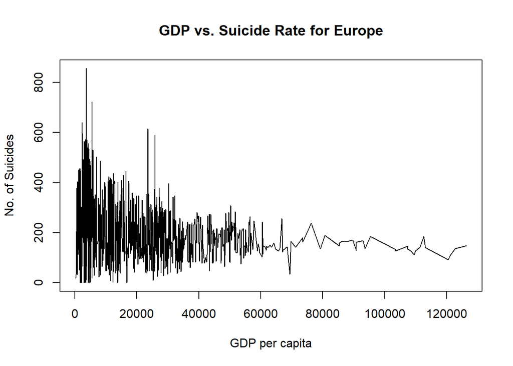

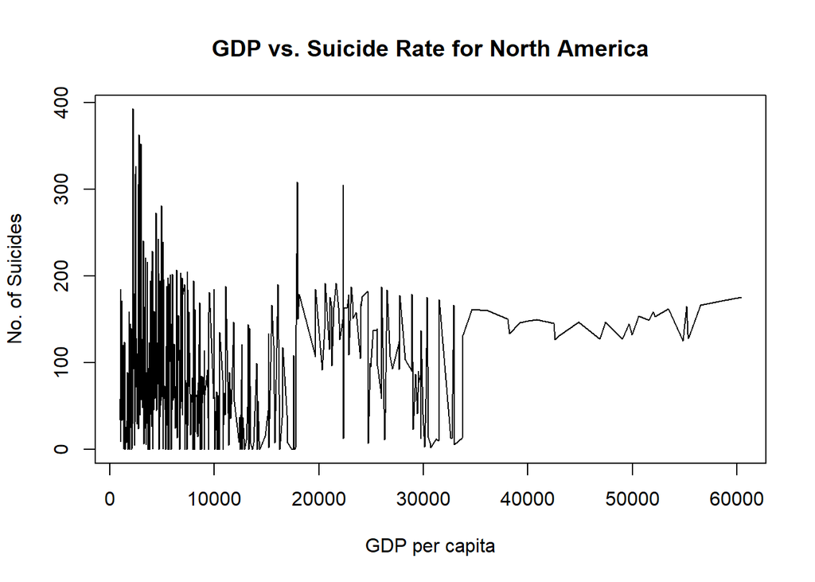

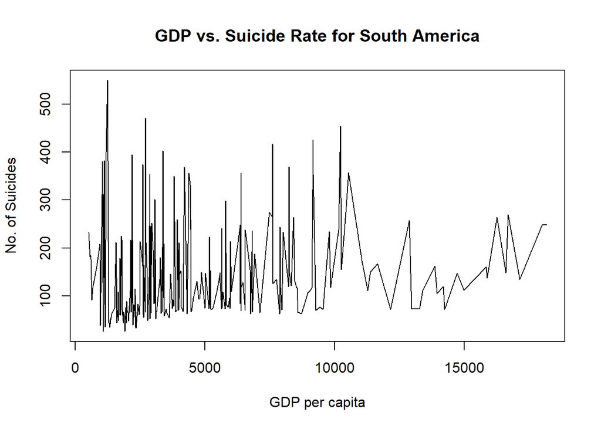

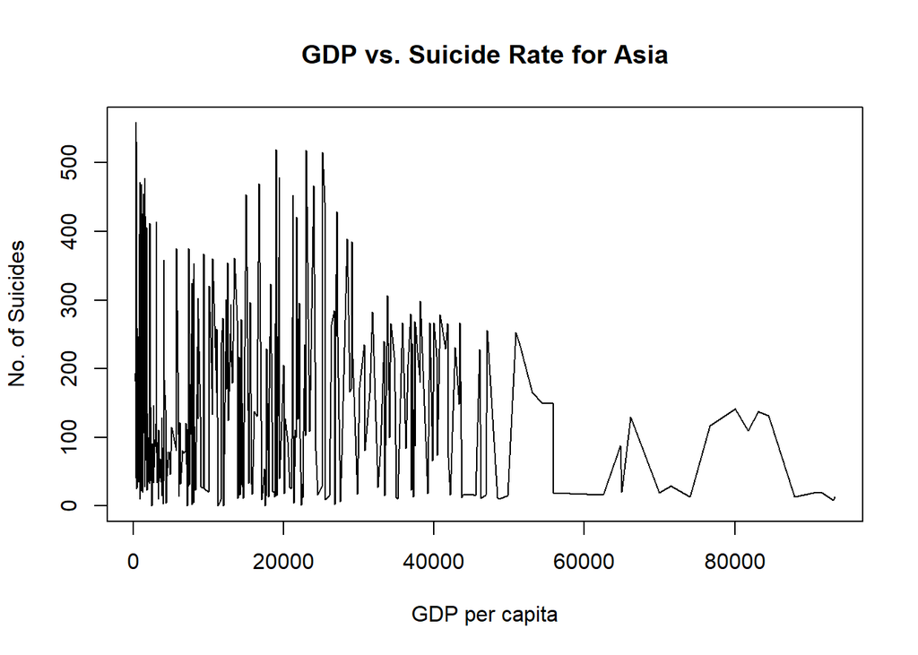

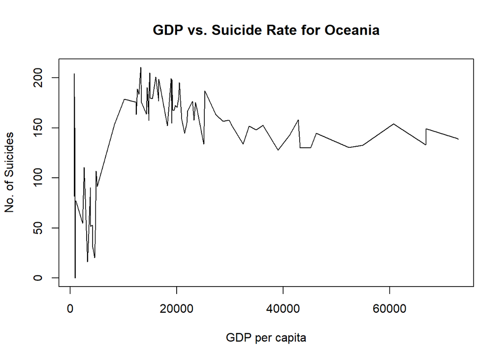

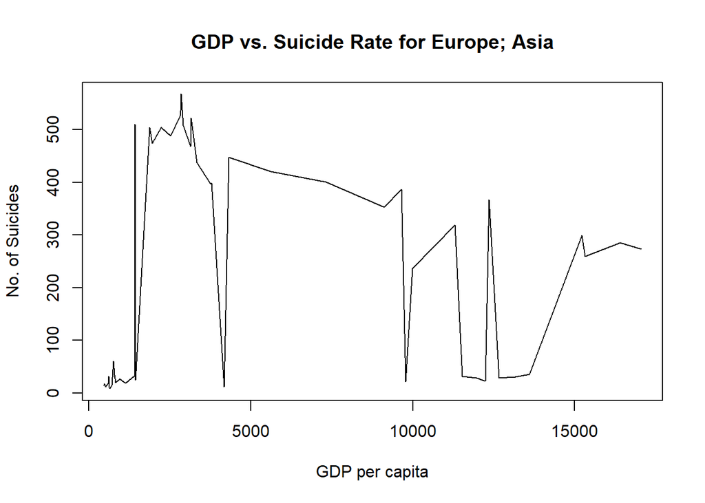

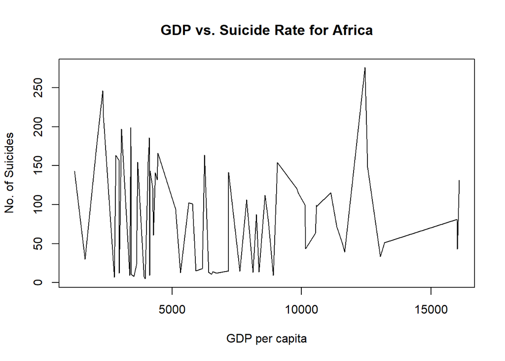

Result: We observe that the GDP per capita has no correlation with the number of suicides per capita.

Remark: Though financial stability on an individual level cannot simply be measured by the per-capita income of a particular region, it still gives us a large scale understanding of the financial states of the residents of a particular region. With a large enough data-set, we can, hence, hope to gauge the general effect of income on the suicide rates.

Let’s observe if the Happiness Index has some connection with financial stability or whether it shows a similar lack of trend as suicide rates.

From our previous analysis, if we want to compare the trend in GDP per capita vs The happiness index, we observe the following plot.

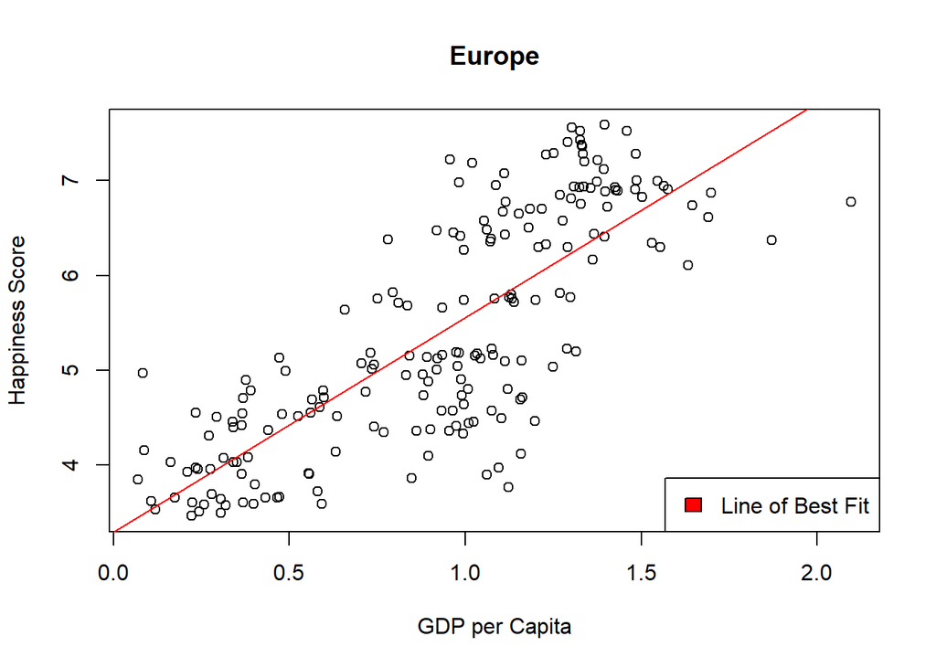

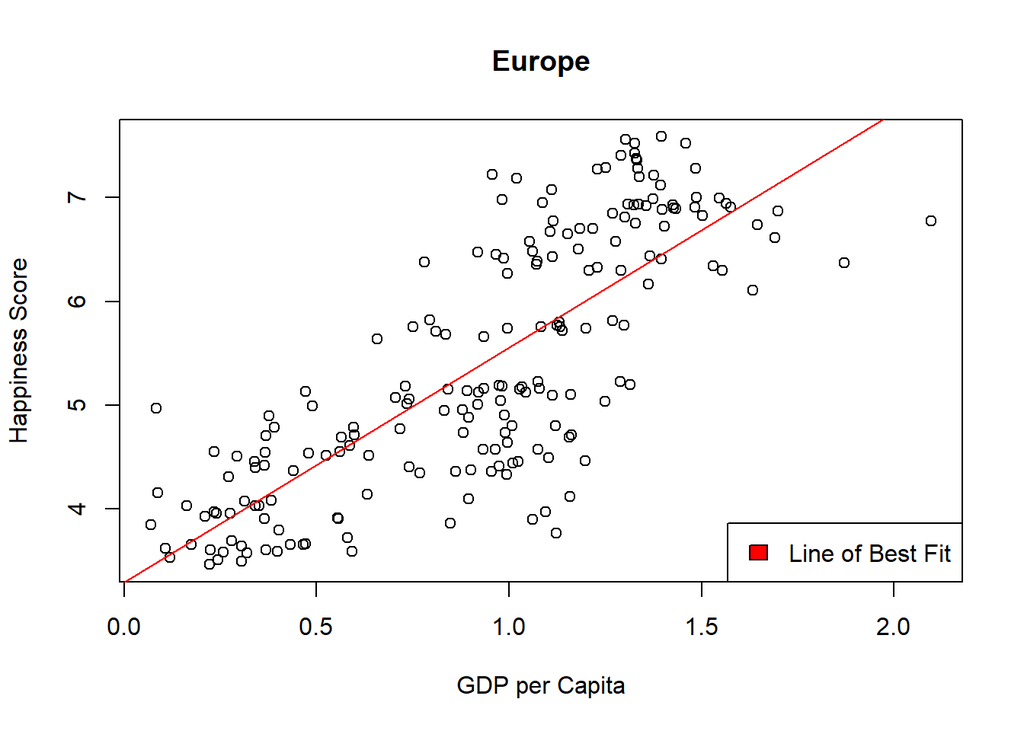

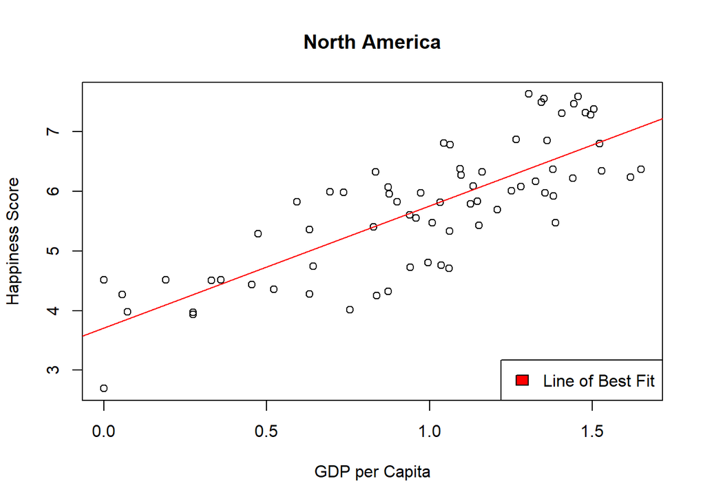

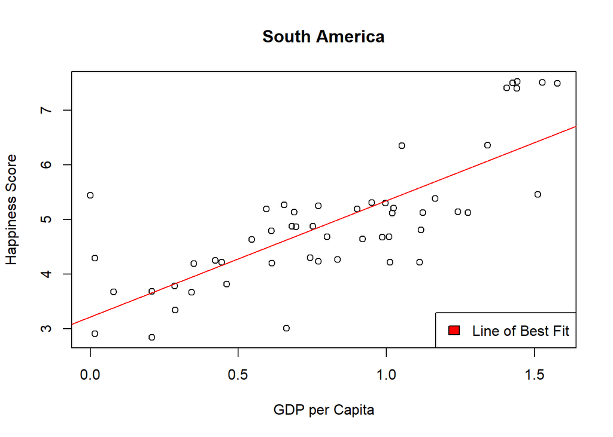

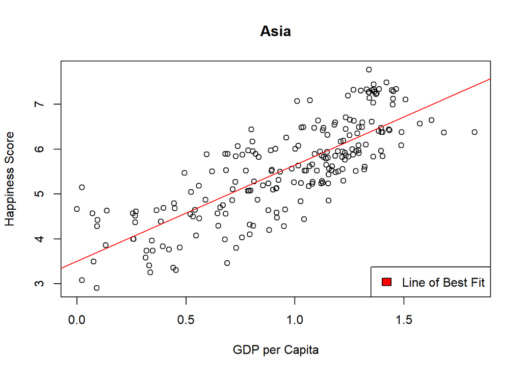

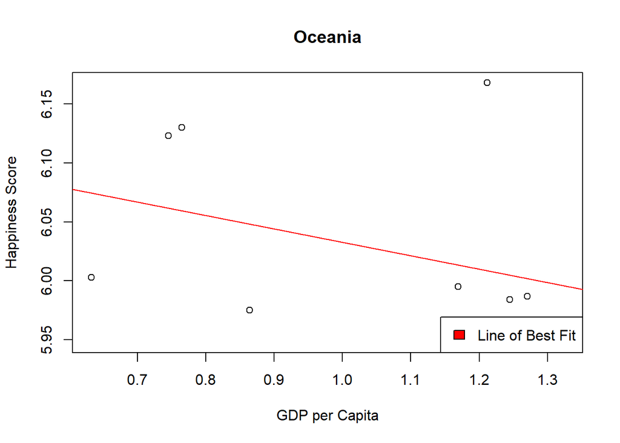

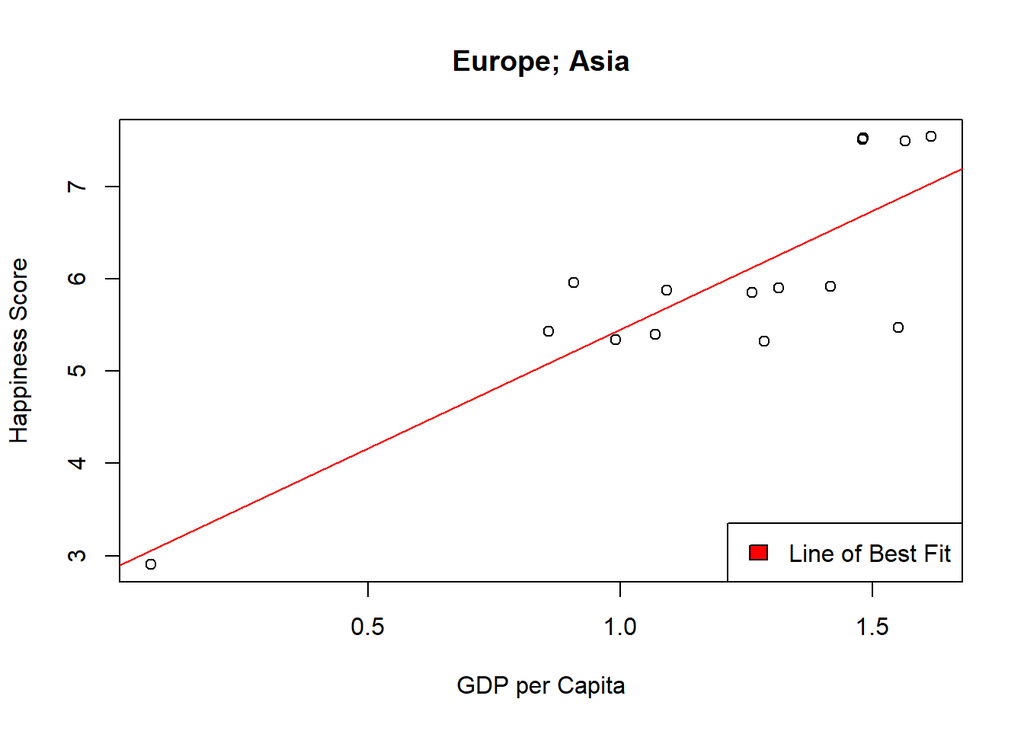

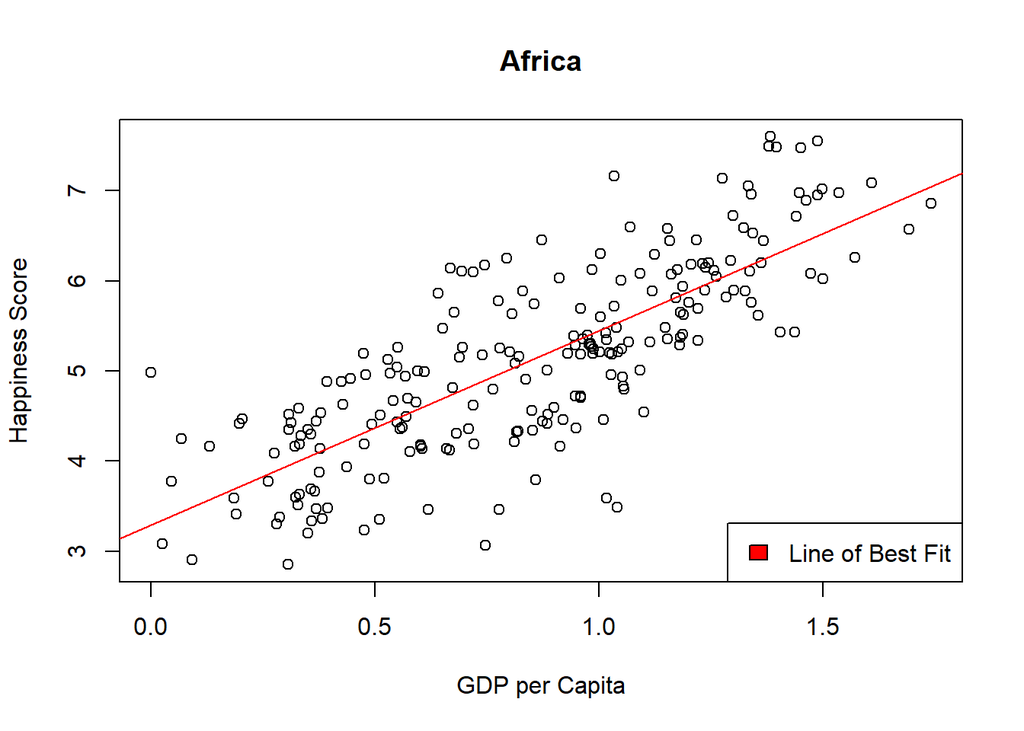

##### Metric 2: Health Conditions

To understand the impact of Health conditions and life expectancy on suicide rates, we can, firstly, establish the claim that GDP per capita and Life expectancy are highly correlated.

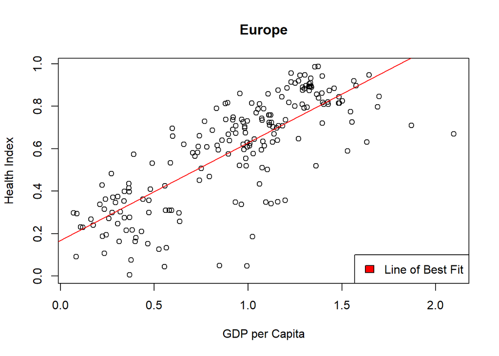

To further substantiate the fact that we have a strong correlation between Health Index and GPD per Capita, we can look at the correlation between the fitted values and the observed values.

```r
cor(dat.happy$Health..Life.Expectancy.,fitted(lm(dat.happy$Health..Life.Expectancy.~dat.happy$Economy..GDP.per.Capita.))) # multiple correlation
```

```
## [1] 0.7816253
```

As expected the correlation values are really high.

| Continents | Corr Values |
| --- | --- |
| Europe | 0.7816253 |
| North America | 0.7613474 |
| South America | 0.8200370 |
| Asia | 0.7950379 |
| Oceania | 0.6440473 |
| Europe; Asia | 0.9459776 |
| Africa | 0.7962161 |

This loosely establishes the fact that financially well-off people tend to have lesser health issues and consequently higher life expectancy. We, however, do not observe such a trend between suicide rates and per-capita income.

##### Metric 3: Region

If we look at the distribution of Happinness across various continents we come across the following plot:

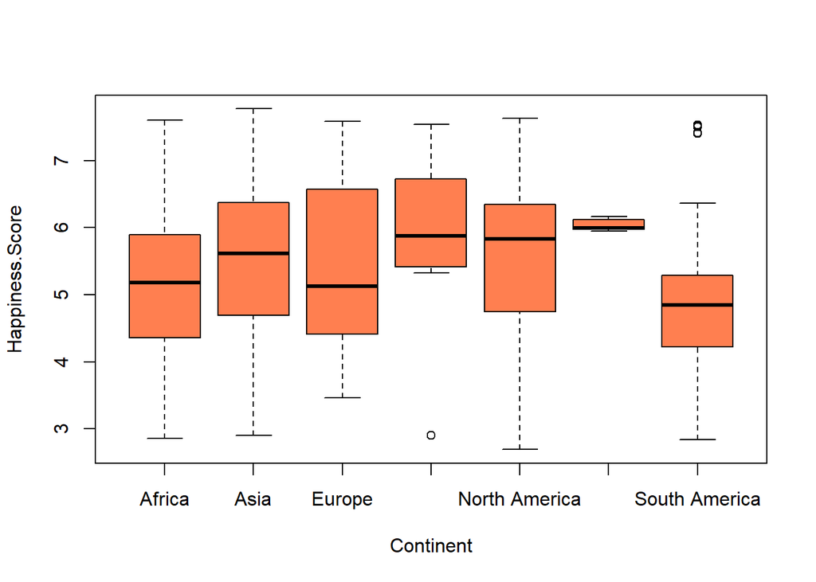

This leads us to believe that there might be several regional and environmental factors that might also lead to a change in the happiness index and symmetrically the suicide rates of that particular region.

```
## [1] "Difference is Mean of happiness index in Upper Hemisphere to Lower Hemisphere : 0.402737286528037"
```

```
## [1] "Deviation in the mean differene : 0.0837894696952222"
```

```
## [1] "Hypothesis : Mean of Upper Hemisphere <= Mean of Bottom Hemisphere"
```

```
## [1] "P value : 7.67830773618501e-07"
```

Since the p value is very low, the hypothesis is rejected. Therefore, Mean of Upper Hemisphere is very likely to be higher than the Mean of the Lower Hemisphere.

##### Metric 4: Age

The question that we want to explore in this section is, “Are people from various age groups more likely to commit suicides?”

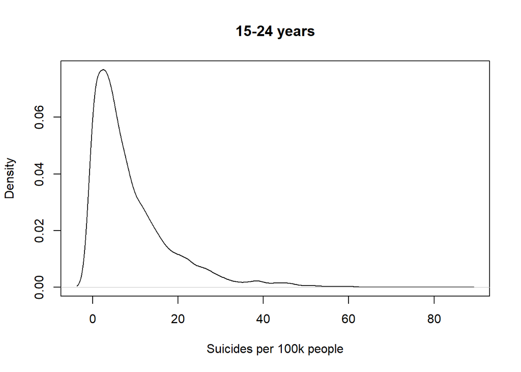

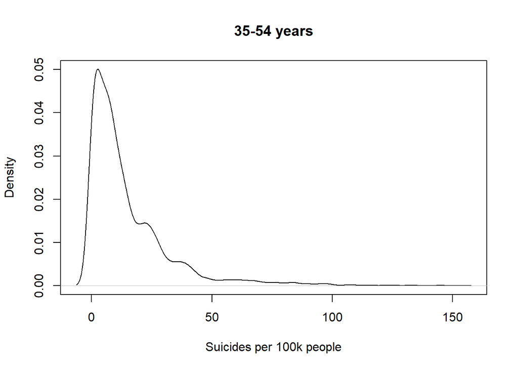

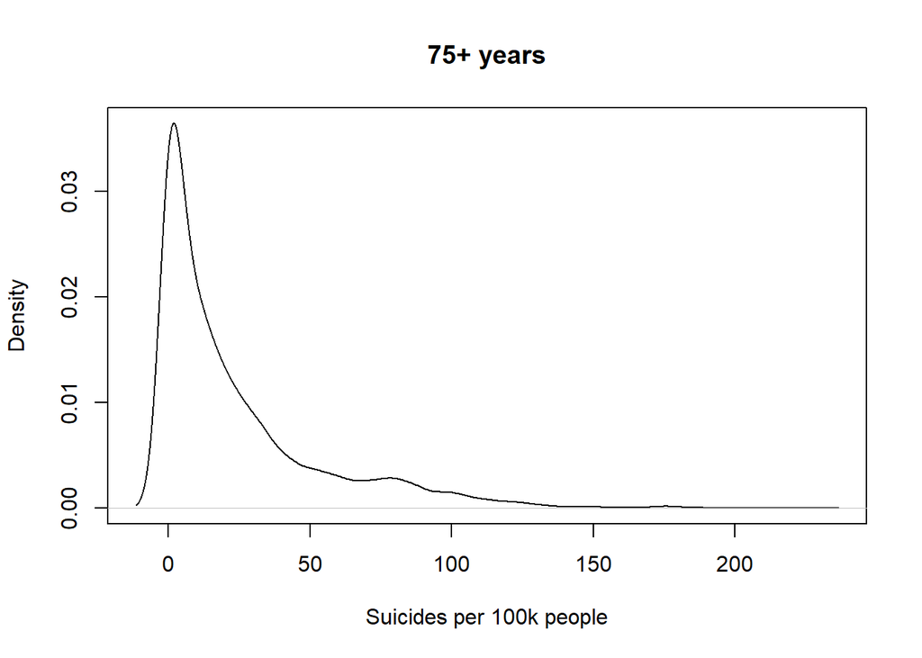

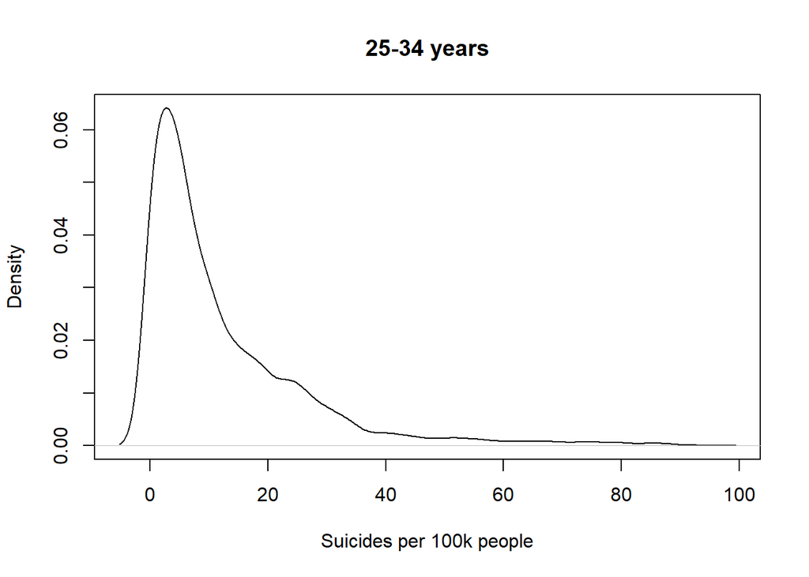

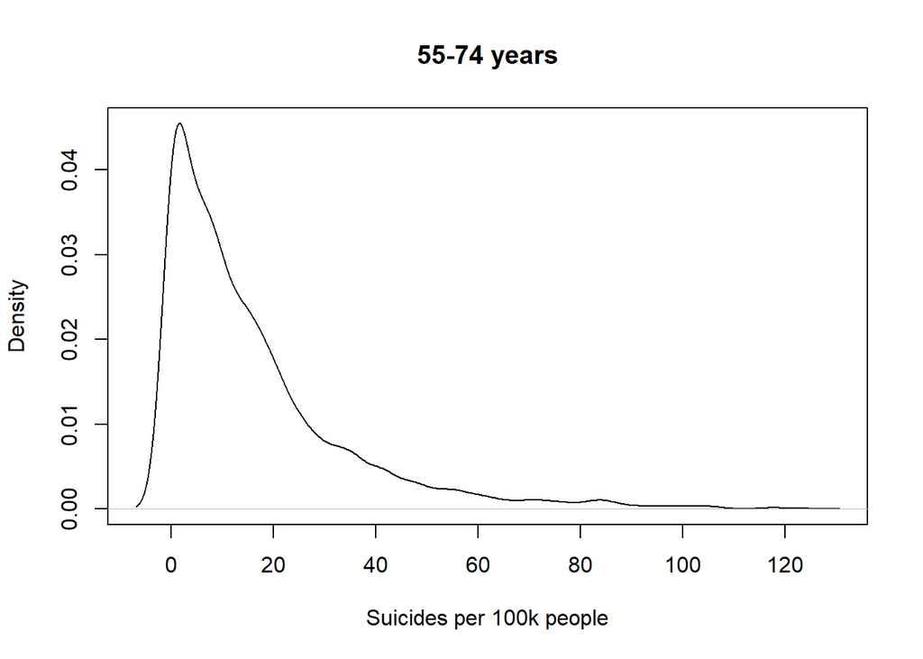

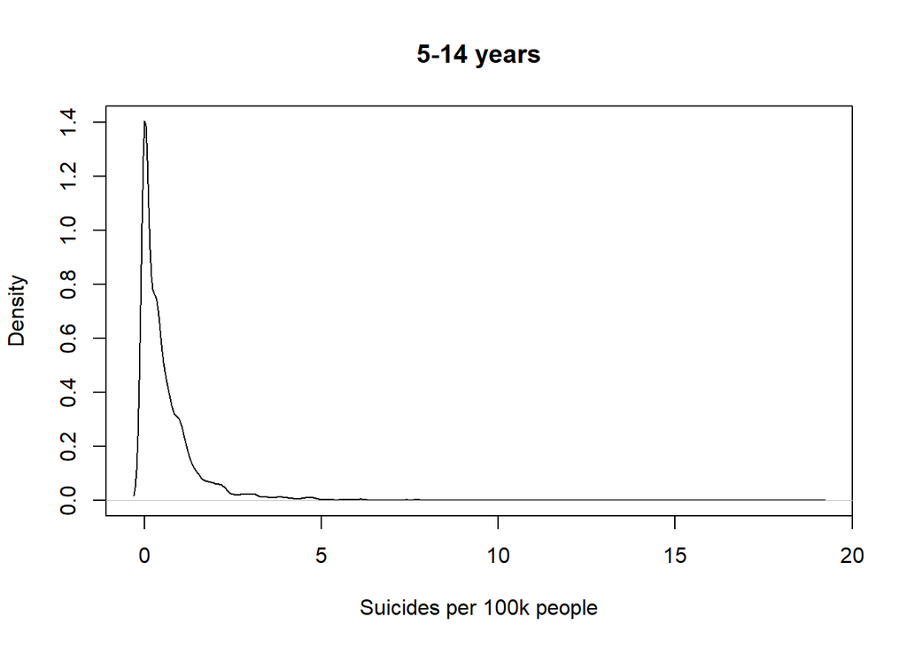

If we look at the mean values for all the different age groups we can derive the following conclusion:

| Age.Groups | Mean Value | Standard Deviation |
| --- | --- | --- |
| 15-24 years | 8.9471542 | 9.578081 |
| 35-54 years | 14.9474408 | 17.700421 |
| 75+ years | 23.9554093 | 30.239147 |
| 25-34 years | 12.1868850 | 14.107455 |
| 55-74 years | 16.1555795 | 18.240465 |
| 5-14 years | 0.6200412 | 1.017878 |

With increasing age you are increasingly likely to commit suicide.

##### Metric 5: Generation

We can also try and analyse how prone each generation is to committing suicides.

| Generation | Mean | Standard Deviation |
| --- | --- | --- |
| Generation X | 10.5568742 | 13.259527 |
| Silent | 18.4188482 | 23.216520 |
| G.I. Generation | 23.9463776 | 29.431211 |
| Boomers | 14.7420942 | 17.443697 |
| Millenials | 5.3835969 | 8.464176 |
| Generation Z | 0.6422993 | 1.044738 |

We can try and analyse a similar understanding in the happiness scores around the globe in these similar generations.

- Silent Generation – 1928-1945
- Boomers – 1946-1964
- Generation X – 1965 - 1980
- Millennials – 1981-1996
- Generation Z – 1997-2012

We can extrapolate the Happiness Index by using the linear model that we derived in the earlier section to check whether a generation more likely to commit suicide was less happy on an average.

| Generation | Mean | Standard Deviation | S.D. of the Mean |
| --- | --- | --- | --- |
| Generation X | 6.796866 | 3.905330 | 0.04878615 |
| Silent | 7.234579 | 4.244954 | 0.05321179 |
| G.I. Generation | 5.648193 | 2.376955 | 0.04537628 |
| Boomers | 6.879968 | 3.993915 | 0.05653905 |
| Millenials | 7.556322 | 4.510664 | 0.05900453 |
| Generation Z | 9.006843 | 5.379159 | 0.14029938 |

##### Metric 6: Continent

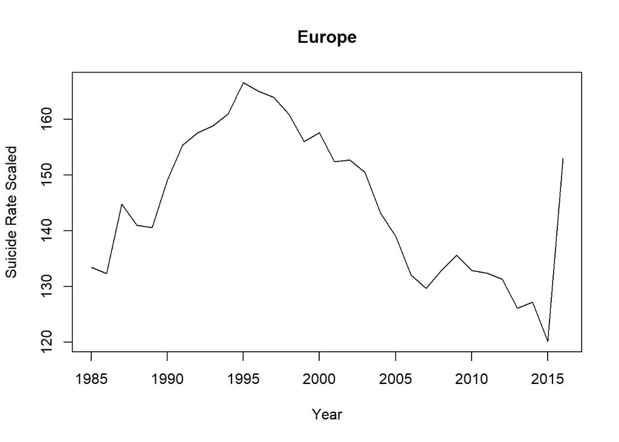

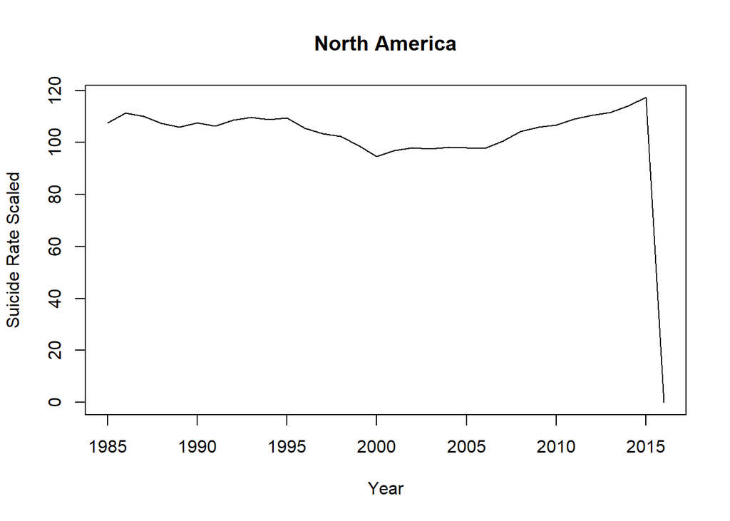

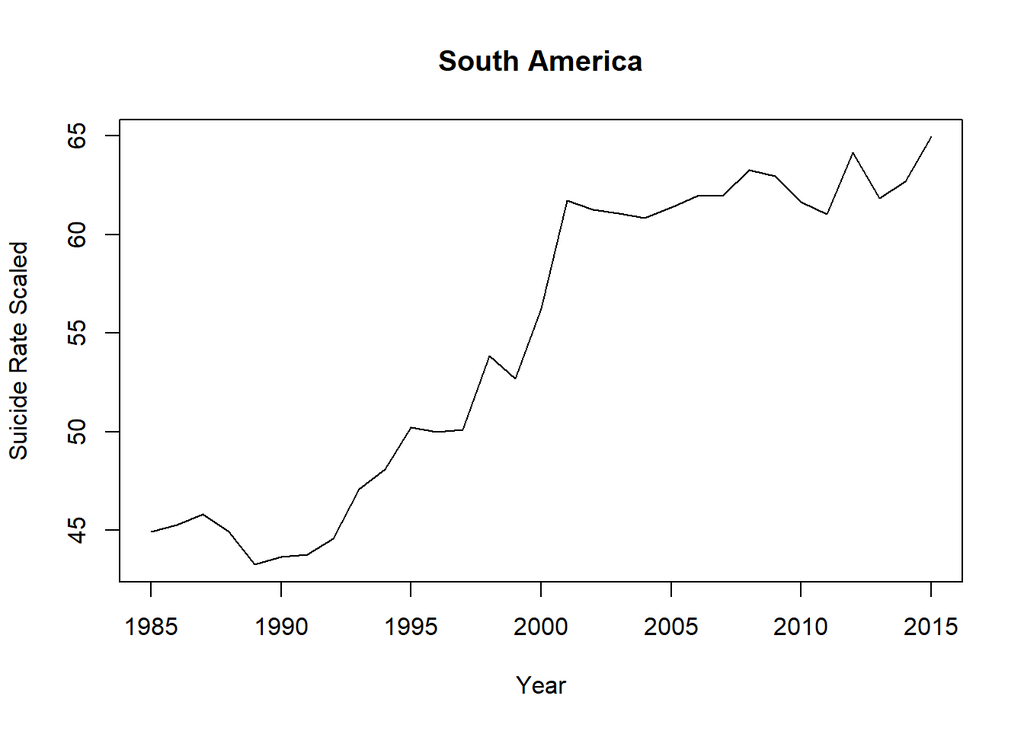

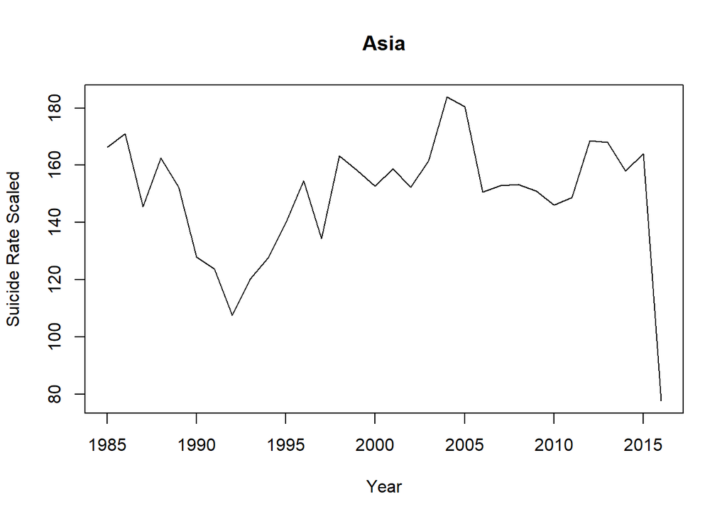

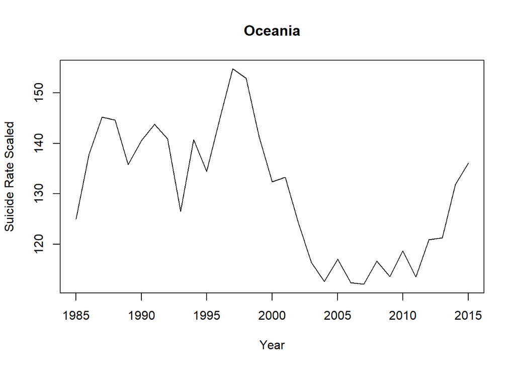

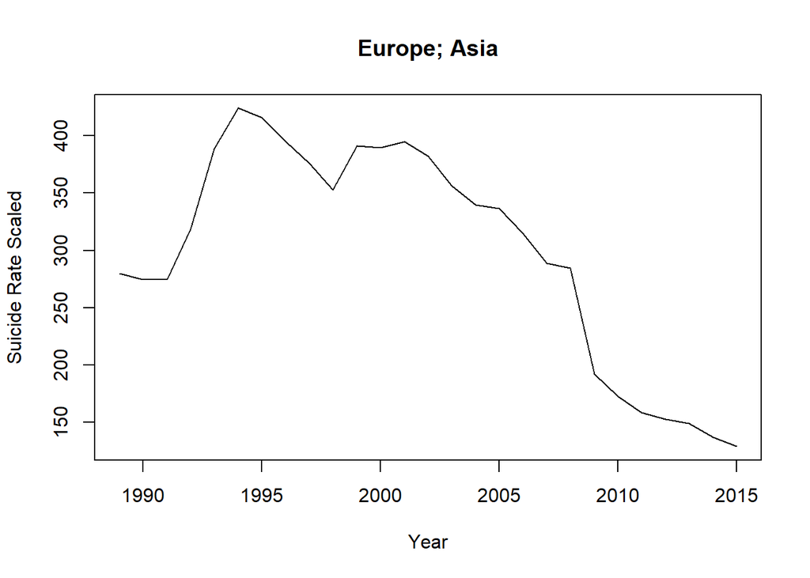

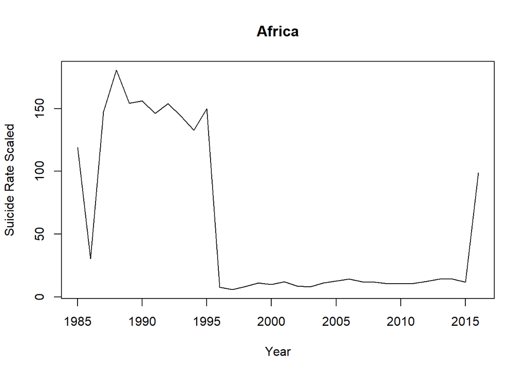

### Final Data

With that motivation set, we can look at our final merged data-set that helps us perform cross analysis of all of our parameters.

|  | X | Happiness.Rank | Happiness.Score | Economy..GDP.per.Capita. | Health..Life.Expectancy. | suicide.tot.normal | Year | Country | continent |
| --- | --- | --- | --- | --- | --- | --- | --- | --- | --- |
| 1 | Argentina2015 | 30 | 6.574 | 1.05351 | 0.78723 | 77.40627 | 2015 | Argentina | Europe |
| 2 | Armenia2015 | 127 | 4.350 | 0.76821 | 0.72990 | 26.47268 | 2015 | Armenia | Europe |
| 3 | Armenia2016 | 121 | 4.360 | 0.86086 | 0.64083 | 27.91628 | 2016 | Armenia | Europe |
| 4 | Australia2015 | 10 | 7.284 | 1.33358 | 0.93156 | 136.10131 | 2015 | Australia | Europe |
| 5 | Austria2015 | 13 | 7.200 | 1.33723 | 0.89042 | 152.20115 | 2015 | Austria | Europe |
| 6 | Austria2016 | 12 | 7.119 | 1.45038 | 0.80565 | 160.46220 | 2016 | Austria | Asia |

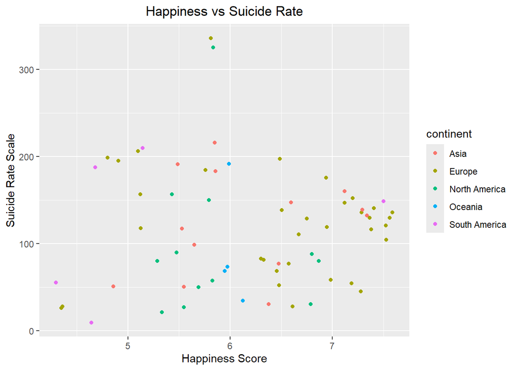

```
## [1] "Correlation - 0.0214553875000274"
```

As can be seen, there is very little correlation between happiness index and suicide rate, which is a surprising result.

### SVM Analysis

Having proved that happiness and suicide rates are uncorrelated, we can go on to attempt to predict happiness values based purely on GDP and life expectancies. Obviously there are a lot more features, not present in this data , that might impact Happiness, but if the predicted values are fairly close to reported values, then this lends confidence to the model but also validates the analysis that it is independent of suicide rates.

```
## [1] "Mean Absolute Percentage error of the SVM model = 9.38326673577373"
```

```
## [1] "Mean Squared Error of the SVM model = 0.35975755938666"
```

```
## [1] "Mean Absolute Percentage error of the SVM model with PCA = 9.58733977594366"
```

```
## [1] "Mean Squared Error of the SVM model with PCA = 0.384836038351249"
```

Thus the SVM model (without implementing PCA) gives us a MAPE of about 0.09 and a MSE of about 0.36. So the model is able to predict happiness scores pretty well, just purely based on GDP and life expectancy, lending credibility to the two metrics as a good indicator of quality of life and hence reported happiness of the people.